# MECH476: Engineering Data Analysis in R

Chapter 6 Homework: Strings, Dates, and Tidying

Genevieve Reyland-Slawson

11 October, 2023

# Chapter 6 Homework

For this homework assignment, you will use data from Twitter that include tweets (2011 to 2017) from Colorado senators, which can be downloaded from Canvas. Just FYI—some tweets were cut off before Twitter’s character limit; just work with the data you have. The original data are from [FiveThirtyEight](https://github.com/fivethirtyeight/data/tree/master/twitter-ratio).

When a question asks you to make a plot, remember to set a theme, title, subtitle, labels, colors, etc. It is up to you how to personalize your plots, but put in some effort and think about making the plotting approach consistent throughout the document. For example, you could use the same theme for all plots. I also like to use the subtitle as a place for the main summary for the viewer.

## Question 1: Hashtags

Within a pipeline using the Colorado-only tweet data, select `text` variable and use `stringr::str_extract_all()` with a pattern of `"#(\\d|\\w)+"` to extract all of the hashtags from the tweets. This will return a list with one element. How many hashtags were used by Colorado senators? –> 5436 hashtags

```r
# wildfire hashtag list
library(tidyverse)
library(stringr)
csv_path <- "/Users/genevieve/Reyland-MECH476/data/senators_co.csv"
senators_data <- readr::read_csv(file = csv_path)
hashtags <- stringr::str_extract_all(string = senators_data$text,
                                     pattern = "#(\\d|\\w)+")
```

## Question 2: Fires

Colorado is on fire right now and has experienced many wildfires over the years. Let’s examine senators’ tweet activity related to wildfires based on hashtags. Using the character vector of hashtags you extracted in Question 1, search for the hashtags that include “fire” or “wildfire”. How many hashtags included “fire”? How many included “wildfire”?

–> There are 16 hashtags that include the word fire. There are 8 hashtags that include the word wildfire.

```r
hashtag_fire <- stringr::str_subset(string = hashtags,
                                    pattern = "fire")
hashtag_wilfire <- stringr::str_subset(string = hashtags,
                                       pattern = "wildfire")
```

## Question 3: Wildfires

Now, let’s look at general tweets concerning wildfires. First, subset the data to a dataframe that includes tweets containing the word “wildfire” and their corresponding timestamp and user. Specifically, (a) select `text`, `date`, and `user` and (b) filter to text strings that include the word “wildfire” using `dplyr::filter()` and `stringr::str_detect()`.

```r
# filter to tweets concerning wildfires
wildfire <- senators_data %>%
  dplyr::select(text, created_at, user) %>%
  dplyr::filter(stringr::str_detect(text, "wildfire"))
```

## Question 4: Senators

Which Colorado senator tweets more about wildfires?

–> Senator Bennet tweets more about wildfires at 20 tweets whereas Cory Gardner tweeted 13 times about wildfires.

```r
# number of wildfire tweets by senator
wildfire %>%
  dplyr::group_by(user) %>%
  dplyr::tally() %>%
  dplyr::ungroup()
```

```
## # A tibble: 2 × 2
##   user               n
##   <chr>          <int>
## 1 SenBennetCO       20
## 2 SenCoryGardner    13
```

## Question 5: Timing

Using the same `wildfires` dataframe, create a summary table that shows the number of tweets containing the word “wildfire” by year (2011-2017). Which year has the most tweets about wildfires? Why might this be the case? (Hint: Think about what happened in the previous year.)

```r
# number of wildfire tweets by year
wildfire_timing <- wildfire %>%
  dplyr::mutate(date = lubridate::mdy_hm(created_at),
                year = lubridate::year(date)) %>%
  dplyr::group_by(user, year) %>%
  dplyr::tally() %>%
  dplyr::ungroup()
```

## Question 6: Monthly tweets

Create a bar chart that answers the question: Are Colorado senators more active at a certain time of year? Hints: Convert `month` to a factor. Fill by `user`.

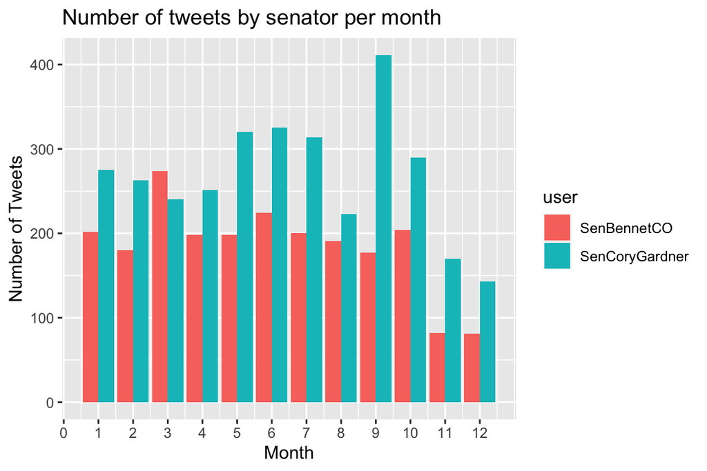

```r
# create plot of tweets by month and user
month_tweets <- senators_data %>%
  dplyr::select(text, created_at, user) %>%
  dplyr::mutate(date = lubridate::mdy_hm(created_at),
                month = lubridate::month(date)) %>%
  dplyr::group_by(month, user) %>%
  dplyr::tally() %>%
  dplyr::ungroup()

library(ggplot2)
ggplot(data = month_tweets,
       mapping = aes(x = month,
                     y = n,
                     fill = user)) +
  geom_bar(stat = "identity",
           position = "dodge") +
  labs(x = "Month",
       y = "Number of Tweets",
       title = "Number of tweets by senator per month") +
  scale_x_continuous(breaks = seq(from = 0,
                                  to = 12,
                                  by = 1))
```

```r
theme_classic()
```

[output not shown]

[output not shown]

## Question 7: Hourly tweets

Create a histogram of tweets by hour of day to visualize when our senators are tweeting.

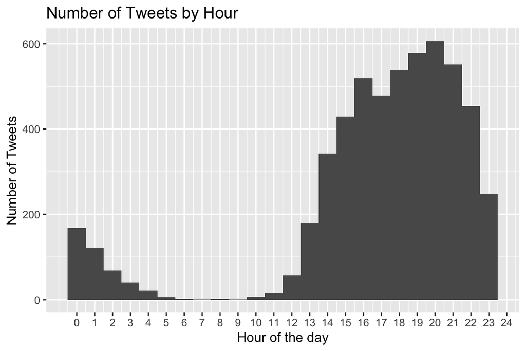

```r
hour_tweets <- senators_data %>%
  dplyr::select(text, created_at, user) %>%
  dplyr::mutate(date = lubridate::mdy_hm(created_at),
                hour = lubridate::hour(date))

ggplot(hour_tweets,
       aes(x = hour)) +
  geom_histogram(binwidth = 1) +
  labs(title = "Number of Tweets by Hour",
       x = "Hour of the day",
       y = "Number of Tweets") +
  scale_x_continuous(breaks = seq(from = 0,
                                  to = 24,
                                  by = 1))
```

```r
  theme_minimal()
```

[output not shown]

[output not shown]

# Appendix

```r
# set global options for figures, code, warnings, and messages
knitr::opts_chunk$set(fig.width=6, fig.height=4, fig.path="../figs/",
                      echo=TRUE, warning=FALSE, message=FALSE)
# wildfire hashtag list
library(tidyverse)
library(stringr)
csv_path <- "/Users/genevieve/Reyland-MECH476/data/senators_co.csv"
senators_data <- readr::read_csv(file = csv_path)
hashtags <- stringr::str_extract_all(string = senators_data$text,
                                     pattern = "#(\\d|\\w)+")
hashtag_fire <- stringr::str_subset(string = hashtags,
                                    pattern = "fire")
hashtag_wilfire <- stringr::str_subset(string = hashtags,
                                       pattern = "wildfire")

# filter to tweets concerning wildfires
wildfire <- senators_data %>%
  dplyr::select(text, created_at, user) %>%
  dplyr::filter(stringr::str_detect(text, "wildfire"))
# number of wildfire tweets by senator
wildfire %>%
  dplyr::group_by(user) %>%
  dplyr::tally() %>%
  dplyr::ungroup()
# number of wildfire tweets by year
wildfire_timing <- wildfire %>%
  dplyr::mutate(date = lubridate::mdy_hm(created_at),
                year = lubridate::year(date)) %>%
  dplyr::group_by(user, year) %>%
  dplyr::tally() %>%
  dplyr::ungroup()
# create plot of tweets by month and user
month_tweets <- senators_data %>%
  dplyr::select(text, created_at, user) %>%
  dplyr::mutate(date = lubridate::mdy_hm(created_at),
                month = lubridate::month(date)) %>%
  dplyr::group_by(month, user) %>%
  dplyr::tally() %>%
  dplyr::ungroup()

library(ggplot2)
ggplot(data = month_tweets,
       mapping = aes(x = month,
                     y = n,
                     fill = user)) +
  geom_bar(stat = "identity",
           position = "dodge") +
  labs(x = "Month",
       y = "Number of Tweets",
       title = "Number of tweets by senator per month") +
  scale_x_continuous(breaks = seq(from = 0,
                                  to = 12,
                                  by = 1))
theme_classic()
hour_tweets <- senators_data %>%
  dplyr::select(text, created_at, user) %>%
  dplyr::mutate(date = lubridate::mdy_hm(created_at),
                hour = lubridate::hour(date))

ggplot(hour_tweets,
       aes(x = hour)) +
  geom_histogram(binwidth = 1) +
  labs(title = "Number of Tweets by Hour",
       x = "Hour of the day",
       y = "Number of Tweets") +
  scale_x_continuous(breaks = seq(from = 0,
                                  to = 24,
                                  by = 1))
  theme_minimal()
```